# mapping

2022-10-21

Mapping (15 points)

Topics to Cover:

Either mapping with the maps package OR mapping from a shapefile. Many shapefiles can be found at https://www.census.gov/geographies/mapping-files/time-series/geo/carto-boundary-file.html Make sure to include:

(4 points) An introductory statement with the goal of the section (in your own words) and a brief description of the data set and variables you will be using.

(11 points) R code chunks interspersed with some text descriptions about the code you have written and with text description about each topic. If you are using the maps package, you should use a map other than the U.S. States Map or World Map that we used in class.

This explores mapping, which visualizes patterns across space. I will use the maps package to visualise France, and then specifically look at data with the regions of france and 2022 population.

With a basic map of France, I will color by region

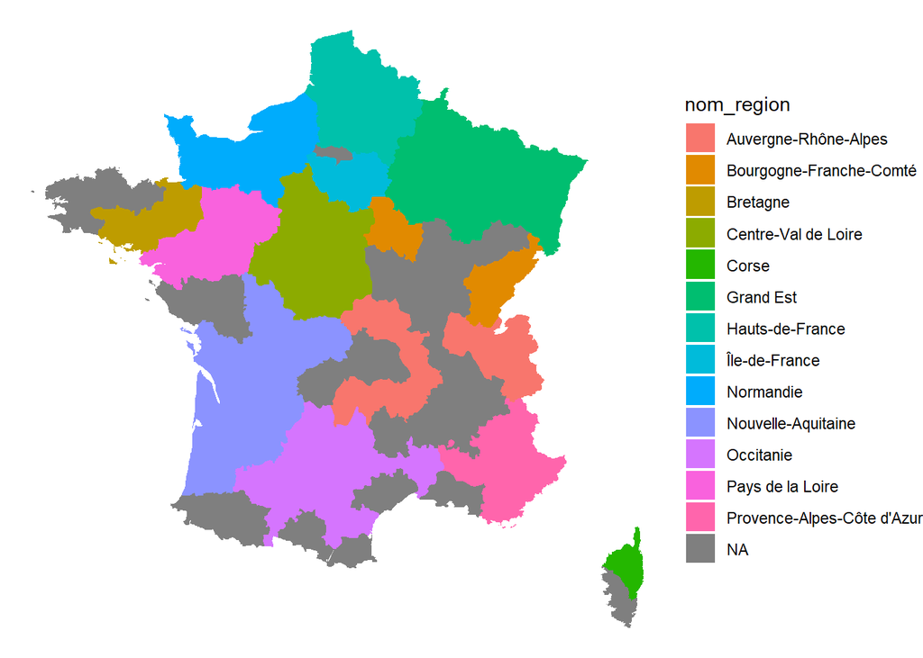

```r
library(maps)
library(tidyverse)
france <- ggplot2::map_data("france")
france_regions <- read.csv("data/departements-france.csv")
library(readxl)
france_pop <- read_excel("data/fr_pop.xls")

france_final <- left_join(france, france_regions, by = c("region" = "nom_departement"))
france_final <- left_join(france_final, france_pop, by = c("nom_region" = "region"))

ggplot(data = france_final,
            mapping = aes(x = long, y = lat,
                          group = group, fill = nom_region)) +
  geom_polygon() +
  theme_void()
```

Now I will color by population per region using a sequential color scheme.

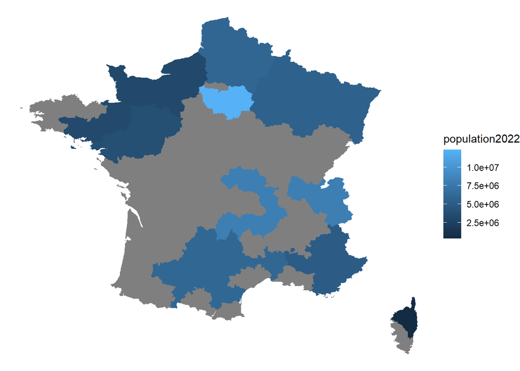

```r
ggplot(data = france_final,
            mapping = aes(x = long, y = lat,
                          group = group, fill = population2022)) +
  geom_polygon() +
  theme_void()
```

Unfortunately, with the constantly changing borders and region/department names in France, we are left with inconsistent data that shows why France is a hard country to cleanly visualize as compared to when we visualized the us states.